# Eurovision Song Contest country profile

2025-05-02

# Norway

## Participation and successes

Norway has participated in the Eurovision Song Contest 62 times. It made it to the final round 59 times - that’s 95.2%.

Norway has won 3 times. Its most successful performance took place in the 2009 final, when the country got 15.9% of all possible points.

## Final place distribution

Here’s how many times Norway earned a particular place in the final round of Eurovision:

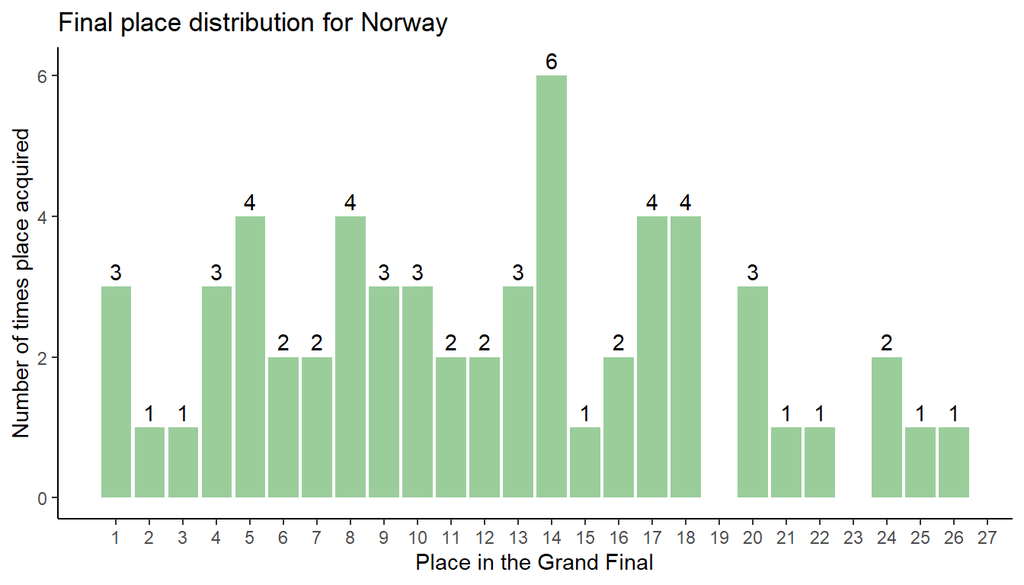

## Loyal besties

Below are the countries that have NEVER given Norway zero points. The bar chart shows the lowest score those countries gave Norway instead.

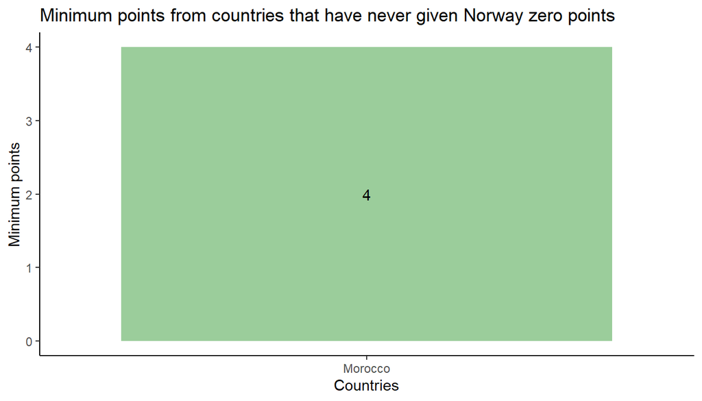

## Only zeros

On the other hand, here are the countries that have never given Norway more than zero points.

```
## Just kidding! No country would do something like that to Norway
```

## Birds of a feather sing together

The European Broadcasting Union started separating televote (votes cast by audience) and jury vote (votes cast by official representatives of each participating country) in 2016. Below is a chart that shows top five countries whose public voted for Norway and top five countries that Norway public voted for the most between 2016 and 2024:

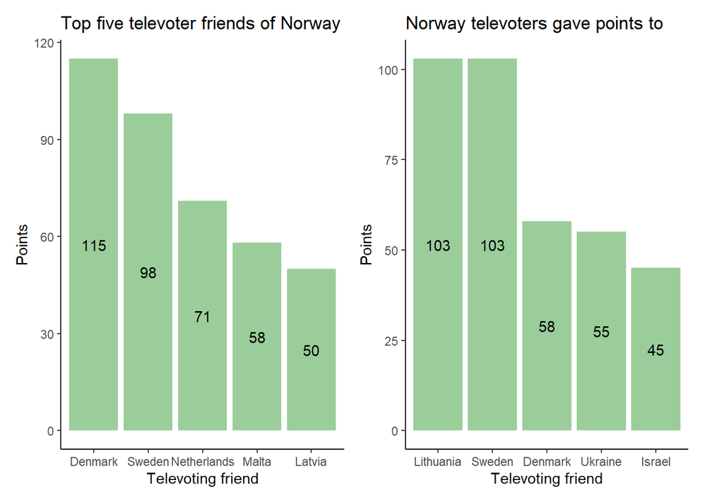

Below is a chart that shows top five countries whose jury voted for Norway and top five countries that Norway jury voted for the most between 2016 and 2024:

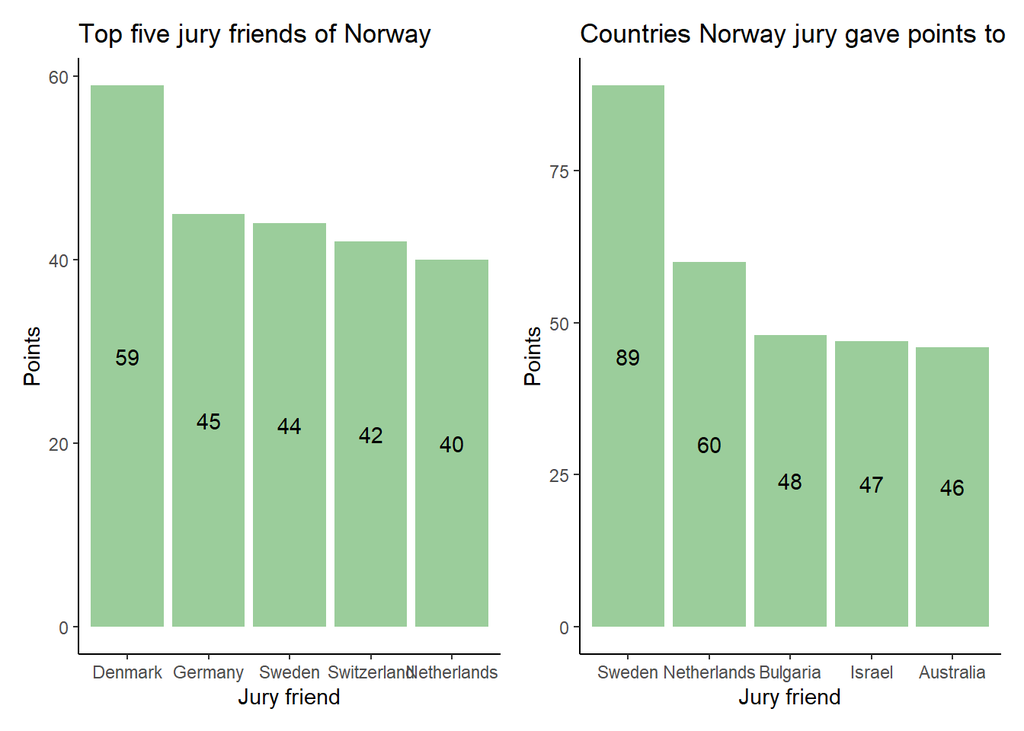

Finally, here is a chart that shows overall (televote and jury vote combined) top five countries that voted for Norway and top five countries that Norway voted for the most between 1957 and 2024:

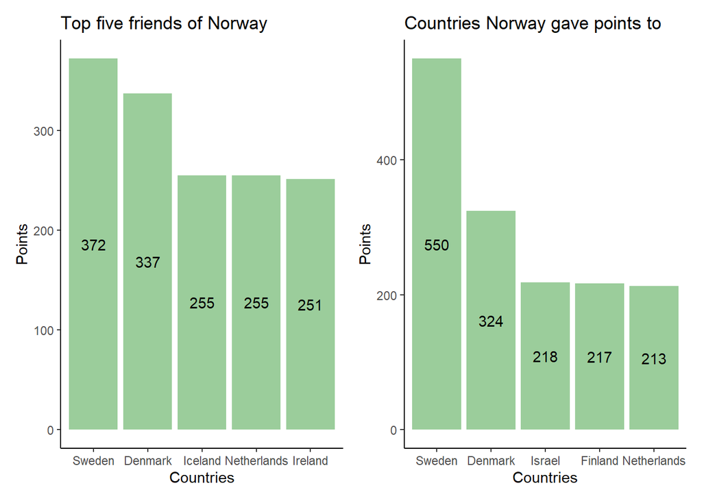